# MovieLens Project Questions-DZ

### Project - MovieLens Data Analysis

The GroupLens Research Project is a research group in the Department of Computer Science and Engineering at the University of Minnesota. The data is widely used for collaborative filtering and other filtering solutions. However, we will be using this data to act as a means to demonstrate our skill in using Python to “play” with data.

#### Domain

Internet and Entertainment

**Note that the project will need you to apply the concepts of groupby and merging extensively.**

Summary

This Project is about making Analysis of MovieLens Case and respective Datasetes in Python and especially performing Exploratory Data Analysis techniques. In order to perform the given tasks and implement the data science solutions, different Python libraries/packages such as NumPy, Pandas, seaborn, matplotlib, were used. This report can be splitted in three main sections and learning outcomes

1. Import, describe and manage the Datasets
2. Perform EDA and Statistical Analysis including many Visualization Techniques
3. Apply more complex techniques of Pandas in order to make better evaluations and judgements.

#### 1. Import the necessary packages

```python
import numpy as np
import pandas as pd
import matplotlib.pyplot as plt
import seaborn as sns
import warnings
sns.set(style="darkgrid")
```

#### 2. Read the 3 datasets into dataframes

```python
data = pd.read_csv("Data.csv")
item = pd.read_csv("item.csv",)#index_col ="movie id"
user = pd.read_csv("user.csv")
```

#### 3. Apply info, shape, describe, and find the number of missing values in the data

```python
print('data.csv Data Info')
print(data.info())
print()
print('data.csv Data Shape')
print(data.shape)
print()
print('data.csv Data Describe')
print(data.describe)
print()
print('Total Number of Missing Values: ', data.isnull().sum().sum())
# Total number of recognised missing values in the entire dataframe
```

```
data.csv Data Info
<class 'pandas.core.frame.DataFrame'>
RangeIndex: 100000 entries, 0 to 99999
Data columns (total 4 columns):
 #   Column     Non-Null Count   Dtype
---  ------     --------------   -----
 0   user id    100000 non-null  int64
 1   movie id   100000 non-null  int64
 2   rating     100000 non-null  int64
 3   timestamp  100000 non-null  int64
dtypes: int64(4)
memory usage: 3.1 MB
None

data.csv Data Shape
(100000, 4)

data.csv Data Describe
<bound method NDFrame.describe of        user id  movie id  rating  timestamp
0          196       242       3  881250949
1          186       302       3  891717742
2           22       377       1  878887116
3          244        51       2  880606923
4          166       346       1  886397596
...        ...       ...     ...        ...
99995      880       476       3  880175444
99996      716       204       5  879795543
99997      276      1090       1  874795795
99998       13       225       2  882399156
99999       12       203       3  879959583

[100000 rows x 4 columns]>

Total Number of Missing Values:  0
```

```python
print('item.csv Data Info')
print(item.info())
print()
print('item.csv Data Shape')
print(item.shape)
print()
print('item.csv Data Describe')
print(item.describe)
print()
print('Total Number of Missing Values: ', item.isnull().sum().sum())  # Total number of recognised missing values in the entire dataframe
```

```
item.csv Data Info
<class 'pandas.core.frame.DataFrame'>
RangeIndex: 1681 entries, 0 to 1680
Data columns (total 22 columns):
 #   Column        Non-Null Count  Dtype
---  ------        --------------  -----
 0   movie id      1681 non-null   int64
 1   movie title   1681 non-null   object
 2   release date  1681 non-null   object
 3   unknown       1681 non-null   int64
 4   Action        1681 non-null   int64
 5   Adventure     1681 non-null   int64
 6   Animation     1681 non-null   int64
 7   Childrens     1681 non-null   int64
 8   Comedy        1681 non-null   int64
 9   Crime         1681 non-null   int64
 10  Documentary   1681 non-null   int64
 11  Drama         1681 non-null   int64
 12  Fantasy       1681 non-null   int64
 13  Film-Noir     1681 non-null   int64
 14  Horror        1681 non-null   int64
 15  Musical       1681 non-null   int64
 16  Mystery       1681 non-null   int64
 17  Romance       1681 non-null   int64
 18  Sci-Fi        1681 non-null   int64
 19  Thriller      1681 non-null   int64
 20  War           1681 non-null   int64
 21  Western       1681 non-null   int64
dtypes: int64(20), object(2)
memory usage: 289.0+ KB
None

item.csv Data Shape
(1681, 22)

item.csv Data Describe
<bound method NDFrame.describe of       movie id                          movie title release date  unknown  \
0            1                           Toy Story   01-Jan-1995        0
1            2                           GoldenEye   01-Jan-1995        0
2            3                          Four Rooms   01-Jan-1995        0
```

[output cut: 36 more lines]

```
0           0
1           0
2           0
3           0
4           0
...       ...
1676        0
1677        0
1678        0
1679        0
1680        0

[1681 rows x 22 columns]>

Total Number of Missing Values:  0
```

```python
print('user.csv Data Info')
print(user.info())
print()
print('user.csv Data Shape')
print(user.shape)
print()
print('user.csv Data Describe')
print(user.describe)
print()
print('Total Number of Missing Values: ', user.isnull().sum().sum())  # Total number of recognised missing values in the entire dataframe
```

```
user.csv Data Info
<class 'pandas.core.frame.DataFrame'>
RangeIndex: 943 entries, 0 to 942
Data columns (total 5 columns):
 #   Column      Non-Null Count  Dtype
---  ------      --------------  -----
 0   user id     943 non-null    int64
 1   age         943 non-null    int64
 2   gender      943 non-null    object
 3   occupation  943 non-null    object
 4   zip code    943 non-null    object
dtypes: int64(2), object(3)
memory usage: 37.0+ KB
None

user.csv Data Shape
(943, 5)

user.csv Data Describe
<bound method NDFrame.describe of      user id  age gender     occupation zip code
0          1   24      M     technician    85711
1          2   53      F          other    94043
2          3   23      M         writer    32067
3          4   24      M     technician    43537
4          5   33      F          other    15213
..       ...  ...    ...            ...      ...
938      939   26      F        student    33319
939      940   32      M  administrator    02215
940      941   20      M        student    97229
941      942   48      F      librarian    78209
942      943   22      M        student    77841

[943 rows x 5 columns]>

Total Number of Missing Values:  0
```

#### 4. Find the number of movies per genre using the item data

```python
# Check
item['movie id'] = item.drop
sum_column = item.sum(axis=0, numeric_only=True)
header = "'Genre'       'Sum'"
print(header)
print(sum_column)
```

```
'Genre'       'Sum'
unknown          1
Action         251
Adventure      135
Animation       42
Childrens      122
Comedy         505
Crime          109
Documentary     50
Drama          725
Fantasy         22
Film-Noir       24
Horror          92
Musical         56
Mystery         61
Romance        247
Sci-Fi         101
Thriller       251
War             71
Western         27
dtype: int64
```

#### 5. Find the movies that have more than one genre

```python
#hint: use sum on the axis = 1
#item['movie id'] = item.drop
#item.drop('movie id',axis=1)
#item.set_index('movie title')
sum_column = item.sum(axis=1)
print(sum_column[sum_column>1])
```

```
0       3
1       3
3       3
4       3
6       2
       ..
1667    3
1668    2
1671    2
1677    2
1678    2
Length: 849, dtype: int64
```

#### 6. Drop the movie where the genre is unknown

```python
item.loc[item['unknown'] == 1]
```

[output not shown]

[output cut: 76 more lines]

[output not shown]

[output not shown]

[output cut: 132 more lines]

[output not shown]

```python
item.drop([1373])
```

[output not shown]

[output cut: 76 more lines]

[output not shown]

[output not shown]

[output cut: 132 more lines]

[output not shown]

### 7. Univariate plots of columns: 'rating', 'Age', 'release year', 'Gender' and 'Occupation'

```python
# HINT: use distplot for age and countplot for gender,ratings,occupation.
# HINT: Please refer to the below snippet to understand how to get to release year from release date. You can use str.split()
# as depicted below
# Hint : Use displot without kde for release year or line plot showing year wise count.
```

```python
a = 'My*cat*is*brown'
print(a.split('*')[2])

#similarly, the release year needs to be taken out from release date

#also you can simply slice existing string to get the desired data, if we want to take out the colour of the cat

print(a[10:])
print(a[-5:])
```

```
is
brown
brown
```

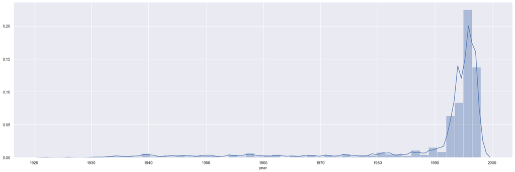

```python
item['year'] = pd.DatetimeIndex(item['release date']).year
plt.figure(figsize=(25,8))
sns.distplot(item.year)
```

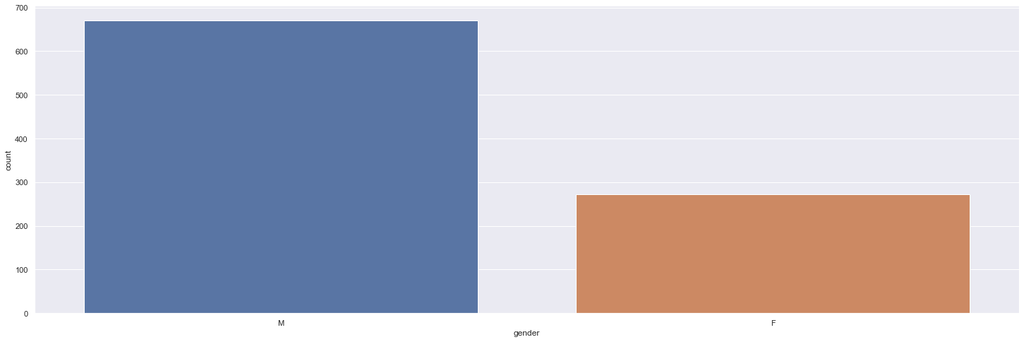

```python
plt.figure(figsize=(25,8))
sns.countplot(user['gender'])
```

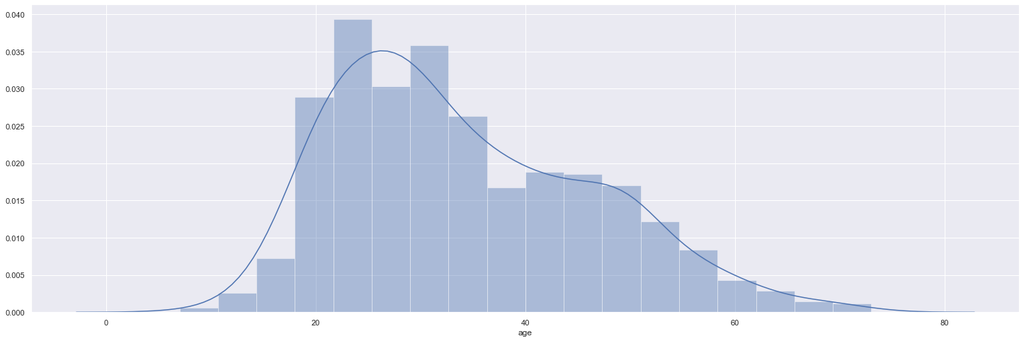

```python
plt.figure(figsize=(25,8))
sns.distplot(user.age)
```

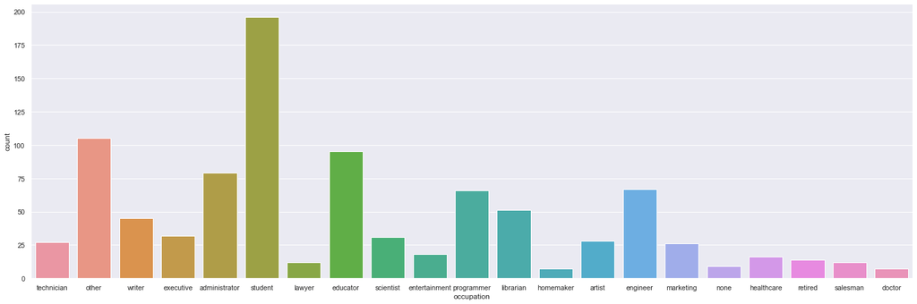

```python
plt.figure(figsize=(25,8))
sns.countplot(user['occupation'])
```

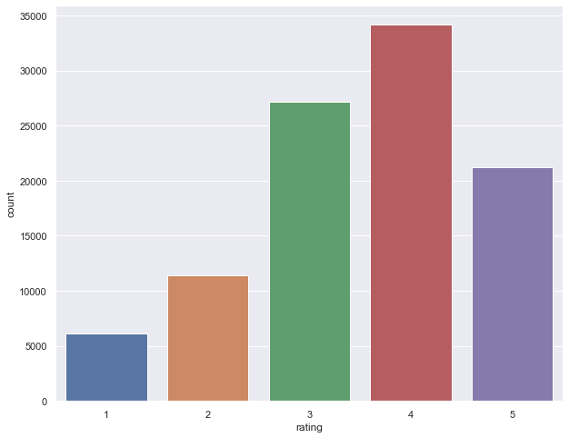

```python
plt.figure(figsize=(10,8))
sns.countplot(data['rating'])
```

### 8. Visualize how popularity of genres has changed over the years - 10 marks

Note that you need to use the number of releases in a year as a parameter of popularity of a genre

Hint

1: you need to reach to a data frame where the release year is the index and the genre is the column names (one cell shows the number of release in a year in one genre) or vice versa. Once that is achieved, you can either use univariate plots or can use the heatmap to visualise all the changes over the years in one go.

Hint 2: Use groupby on the relevant column and use sum() on the same to find out the nuumber of releases in a year/genre.

```python
item.columns
```

```
Index(['movie title', 'release date', 'unknown', 'Action', 'Adventure',
       'Animation', 'Childrens', 'Comedy', 'Crime', 'Documentary', 'Drama',
       'Fantasy', 'Film-Noir', 'Horror', 'Musical', 'Mystery', 'Romance',
       'Sci-Fi', 'Thriller', 'War', 'Western', 'year'],
      dtype='object')
```

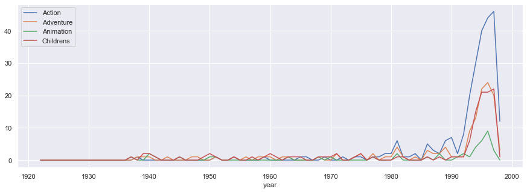

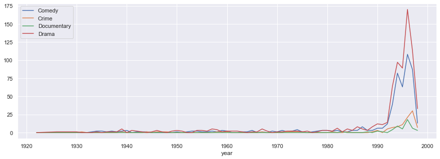

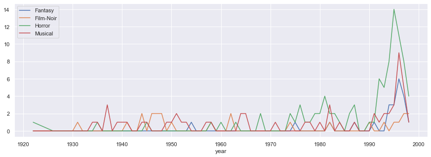

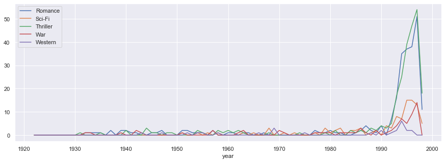

```python
item['year'] = pd.DatetimeIndex(item['release date']).year
# setting first name as index column
#item.set_index("year", inplace = True)

#item.groupby(by=['year'])
item[['year','Action','Adventure','Animation', 'Childrens']].groupby(['year']).sum().plot(figsize=(15,5))
item[['year','Comedy', 'Crime', 'Documentary', 'Drama']].groupby(['year']).sum().plot(figsize=(15,5))
item[['year','Fantasy', 'Film-Noir', 'Horror', 'Musical']].groupby(['year']).sum().plot(figsize=(15,5))
item[['year','Romance','Sci-Fi', 'Thriller', 'War', 'Western']].groupby(['year']).sum().plot(figsize=(15,5))
#plt.show()
#print(item.groupby)
#sum_column1 = item.sum(axis=0, numeric_only=True)
#print(sum_column1)
#plt.show()
#item.head()
```

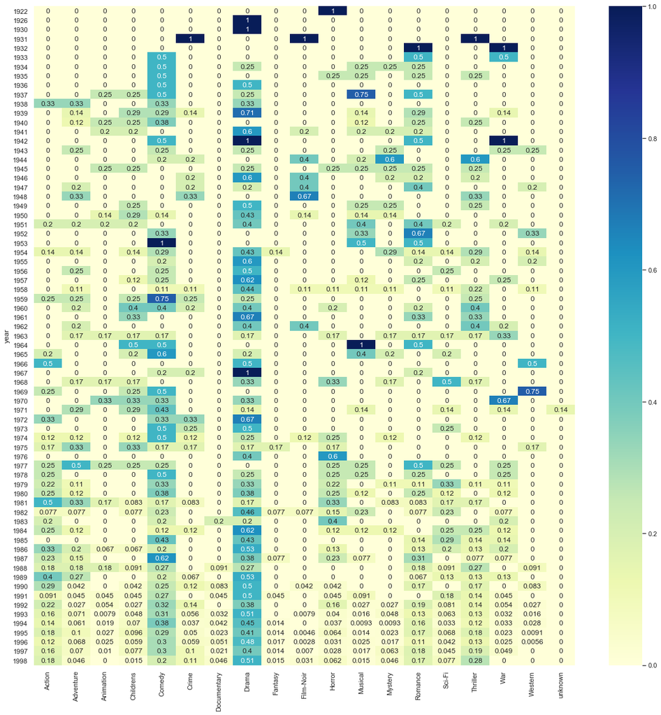

```python
heatmap1_data = pd.pivot_table(item, index=['year'])
plt.figure(figsize=(20,20))
sns.heatmap(heatmap1_data, annot=True, cmap="YlGnBu")
```